# Resampling and Randomization

Data Science for the Psychological Sciences

Paul D. Kieffaber, Ph.D.

### **Module Goal:** To move beyond the assumptions of traditional parametric statistics and introduce computationally-intensive methods (bootstrapping and permutation tests) for generating confidence intervals and p-values.

### **Prerequisites:

- Basic R proficiency (data frames, functions, dplyr).
- Understanding of core statistical concepts (mean, median, p-value, confidence interval).
- Familiarity with parametric tests (t.test(), lm()) and their assumptions (from your previous module).

# Review

## The World of Parametric Assumptions

In our last module, we explored the “workhorses” of statistical analysis: the General Linear Model, which includes both the t.test() and lm(). These tools are powerful, fast, and form the foundation of most statistical analysis. But their power and convenience come at a price. They rely on a strict “statistical contract” — a set of parametric assumptions — to be true.

When we run summary(lm_model), we are implicitly trusting that our data meets these assumptions. If it doesn’t, the p-values and confidence intervals that R prints out can be misleading or just plain wrong.These models, like lm() and t.test(), build their calculations on a few key assumptions about the residuals (the $\epsilon$ error term)

- **Normality:** The residuals are assumed to be drawn from a normal (Gaussian) distribution.
- **Homogeneity of Variance (Homoscedasticity):** The variance of the residuals is assumed to be equal at all levels of the predictor variable.
- **Independence:** The residuals are assumed to be independent of one another. The error for one data point tells you nothing about the error for another.

When these assumptions are incorrect, our standard errors become unreliable. If the residuals aren’t normal, our p-values for a small sample might be incorrect. If variance isn’t homogenous, we might overestimate our confidence in one group and underestimate it in another. And as we saw in the mixed-effects models section, if our data points aren’t independent (like students in a classroom or measurements over time), our model will be wildly over-confident, leading to p-values that are far too small.

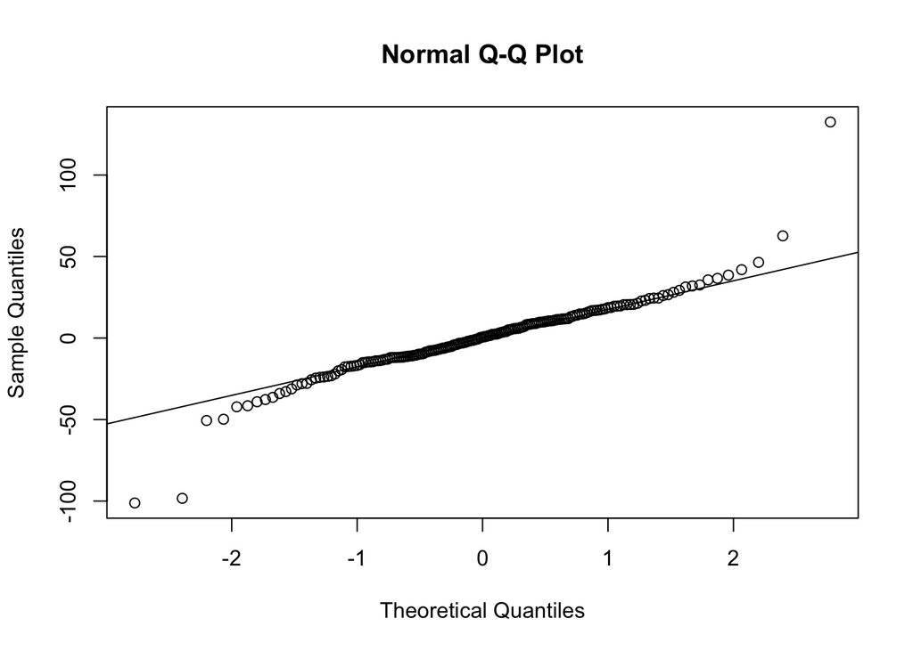

```r
library(lme4)
library(lmerTest)

# Run the full LMM from the LinearModels.Rmd file
data(sleepstudy, package = "lme4")
model_full <- lmer(Reaction ~ Days + (1 + Days | Subject), data = sleepstudy)

# Create the Q-Q plot
qqnorm(residuals(model_full))
qqline(residuals(model_full))
```

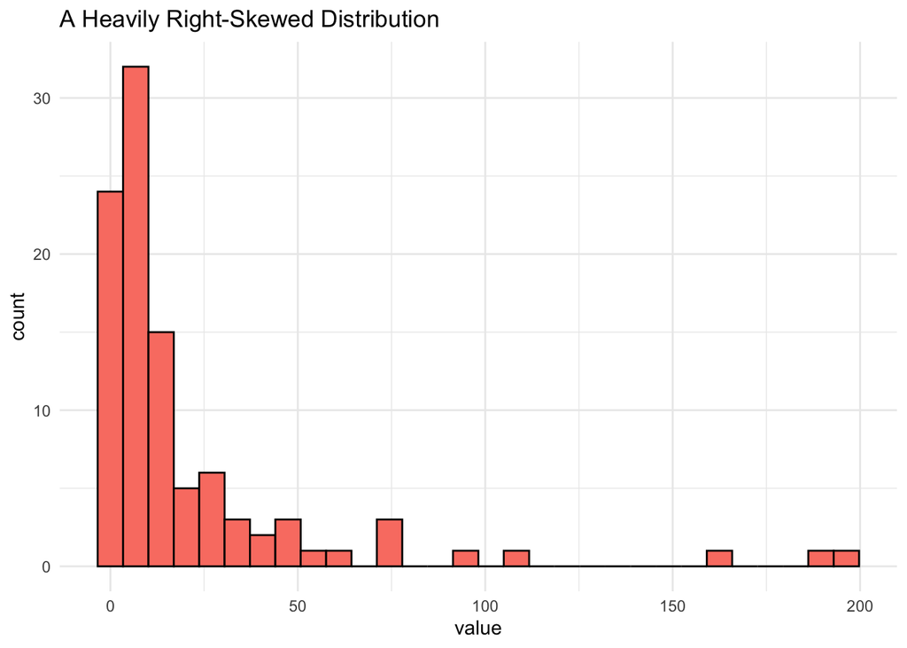

This data is clearly not normal. If we ran a Q-Q plot on it, we’d see a dramatic failure to meet the assumption. The tails of the distribution (the very low and very high values) would curve far away from the diagonal line.

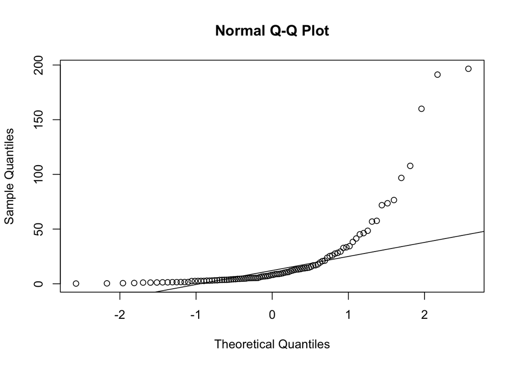

So, what’s the big deal? The t.test is fairly “robust” to violations of normality, right? Yes, but only to a point. When data is this skewed, the mathematical assumptions of the t-distribution break down. The standard errors calculated by t.test() will be incorrect, and therefore the confidence intervals and p-values will be untrustworthy.